# Analisi di regressione sul dataset Film

E.Chiola & P.Iezzi

24/5/2020

# Overview dei dati

```r
library(readr)
library(knitr)
movies_metadata <- read_delim("C:/Users/Patrizio/Desktop/TUTTO/Ud'A/CLEBA/DATA SCIENCE/Primo progetto-Data Science/movies_metadata.csv",
    ";", escape_double = FALSE, trim_ws = TRUE)
```

```r
options(scipen=10)
kable(head(movies_metadata)[1:5,])
```

| title | budget | popularity | revenue | runtime | vote_average | original_language |
| --- | --- | --- | --- | --- | --- | --- |
| Stop Making Sense | 1200000 | 2359569 | 4978922 | 88 | 8.7 | en |
| The Shawshank Redemption | 25000000 | 51645403 | 28341469 | 142 | 8.5 | en |
| The Godfather | 6000000 | 41109264 | 245066411 | 175 | 8.5 | en |
| Whiplash | 3300000 | 6429999 | 13092000 | 105 | 8.3 | en |
| Life Is Beautiful | 20000000 | 3939497 | 229400000 | 116 | 8.3 | it |

```r
train1<-read_delim("C:/Users/Patrizio/Desktop/TUTTO/Ud'A/CLEBA/DATA SCIENCE/Primo progetto-Data Science/movies_metadata.csv",";", escape_double = FALSE, col_types = cols(title = col_skip()), trim_ws = TRUE)
str(train1)
```

```
## tibble [4,086 x 6] (S3: spec_tbl_df/tbl_df/tbl/data.frame)
##  $ budget           : num [1:4086] 1200000 25000000 6000000 3300000 20000000 3000000 63000000 185000000 8000000 22000000 ...
##  $ popularity       : num [1:4086] 2359569 51645403 41109264 6429999 3939497 ...
##  $ revenue          : num [1:4086] 4978922 28341469 245066411 13092000 229400000 ...
##  $ runtime          : num [1:4086] 88 142 175 105 116 133 139 152 154 195 ...
##  $ vote_average     : num [1:4086] 8.7 8.5 8.5 8.3 8.3 8.3 8.3 8.3 8.3 8.3 ...
##  $ original_language: chr [1:4086] "en" "en" "en" "en" ...
##  - attr(*, "spec")=
##   .. cols(
##   ..   title = col_skip(),
##   ..   budget = col_double(),
##   ..   popularity = col_double(),
##   ..   revenue = col_double(),
##   ..   runtime = col_double(),
##   ..   vote_average = col_double(),
##   ..   original_language = col_character()
##   .. )
```

```r
attach(train1)
```

Si procede scalando le variabili esplicative in base milionaria, in modo tale da avere una scala unica.

```r
#scaliamo a base milionaria
train1[,1]<-train1$budget/1000000
train1[,2]<-train1$popularity/1000000
train1[,3]<-train1$revenue/1000000
View(train1)
```

Una volta scalate le variabili si mostra il summary del dataset, effettuando un correlazione tra tutte le variabili quantitative. La variabile original_language sarà analizzata successivamente tramite Dummy.

```r
#summary
summary(train1)
```

```
##      budget         popularity          revenue           runtime
##  Min.   :  1.00   Min.   :  0.0051   Min.   :   1.00   Min.   : 26
##  1st Qu.: 10.00   1st Qu.:  5.8154   1st Qu.:  15.14   1st Qu.: 96
##  Median : 24.00   Median :  8.7343   Median :  46.01   Median :107
##  Mean   : 37.93   Mean   : 10.2259   Mean   : 111.65   Mean   :110
##  3rd Qu.: 50.00   3rd Qu.: 12.0912   3rd Qu.: 126.24   3rd Qu.:120
##  Max.   :380.00   Max.   :547.4883   Max.   :2787.97   Max.   :248
##   vote_average   original_language
##  Min.   :2.800   Length:4086
##  1st Qu.:5.700   Class :character
##  Median :6.300   Mode  :character
##  Mean   :6.286
##  3rd Qu.:6.900
##  Max.   :8.700
```

```r
#correlazione
kable(t(cor(train1[,c(1:5)])))
```

|  | budget | popularity | revenue | runtime | vote_average |
| --- | --- | --- | --- | --- | --- |
| budget | 1.0000000 | 0.2381015 | 0.7140153 | 0.2331390 | -0.0128020 |
| popularity | 0.2381015 | 1.0000000 | 0.3852084 | 0.1009486 | 0.1476983 |
| revenue | 0.7140153 | 0.3852084 | 1.0000000 | 0.2328283 | 0.1975713 |
| runtime | 0.2331390 | 0.1009486 | 0.2328283 | 1.0000000 | 0.3946157 |
| vote_average | -0.0128020 | 0.1476983 | 0.1975713 | 0.3946157 | 1.0000000 |

Una volta effettuata la correlazione tra le variabili, si procede alla rappresentazione grafica delle stesse.

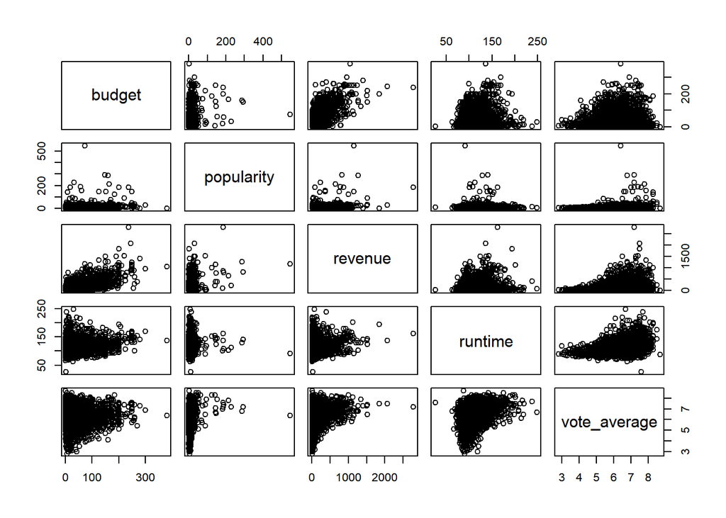

```r
# plot numeriche
plot(train1[c(1,2,3,4,5)])
```

# Analisi di regressione lineare semplice

Si procede con l’analisi di regressione lineare semplice, ponendo come variabilie dipendente **Revenue** e come variabili esplicative tutte le altre.

```r
# Budget
OLS<-lm(revenue~budget)
summary(OLS)
```

```
##
## Call:
## lm(formula = revenue ~ budget)
##
## Residuals:
##        Min         1Q     Median         3Q        Max
## -684396879  -49638830   -9157792   21665318 2069176614
##
## Coefficients:
##                  Estimate    Std. Error t value Pr(>|t|)
## (Intercept) -4039357.4207  2670664.3263  -1.512     0.13
## budget             3.0499        0.0468  65.174   <2e-16 ***
## ---
## Signif. codes:  0 '***' 0.001 '**' 0.01 '*' 0.05 '.' 0.1 ' ' 1
##
## Residual standard error: 127600000 on 4084 degrees of freedom
## Multiple R-squared:  0.5098, Adjusted R-squared:  0.5097
## F-statistic:  4248 on 1 and 4084 DF,  p-value: < 2.2e-16
```

```r
# Popularity
OLS1<-lm(revenue~popularity)
summary(OLS1)
```

```
##
## Call:
## lm(formula = revenue ~ popularity)
##
## Residuals:
##         Min          1Q      Median          3Q         Max
## -1408811332   -80851939   -56290863    18529322  1877730651
##
## Coefficients:
##                  Estimate    Std. Error t value Pr(>|t|)
## (Intercept) 64940317.9259  3159605.3048   20.55   <2e-16 ***
## popularity         4.5674        0.1712   26.68   <2e-16 ***
## ---
## Signif. codes:  0 '***' 0.001 '**' 0.01 '*' 0.05 '.' 0.1 ' ' 1
##
## Residual standard error: 168100000 on 4084 degrees of freedom
## Multiple R-squared:  0.1484, Adjusted R-squared:  0.1482
## F-statistic: 711.6 on 1 and 4084 DF,  p-value: < 2.2e-16
```

```r
# Runtime
OLS2<-lm(revenue~runtime)
summary(OLS2)
```

```
##
## Call:
## lm(formula = revenue ~ runtime)
##
## Residuals:
##        Min         1Q     Median         3Q        Max
## -341563683  -85406499  -50876391   19417479 2565026975
##
## Coefficients:
##               Estimate Std. Error t value Pr(>|t|)
## (Intercept) -124111083   15656629  -7.927 2.87e-15 ***
## runtime        2142279     140022  15.300  < 2e-16 ***
## ---
## Signif. codes:  0 '***' 0.001 '**' 0.01 '*' 0.05 '.' 0.1 ' ' 1
##
## Residual standard error: 177200000 on 4084 degrees of freedom
## Multiple R-squared:  0.05421,    Adjusted R-squared:  0.05398
## F-statistic: 234.1 on 1 and 4084 DF,  p-value: < 2.2e-16
```

```r
# Voto medio
OLS3<-lm(revenue~vote_average)
summary(OLS3)
```

```
##
## Call:
## lm(formula = revenue ~ vote_average)
##
## Residuals:
##        Min         1Q     Median         3Q        Max
## -208957166  -93221731  -50450143   22581112 2637591470
##
## Coefficients:
##                Estimate Std. Error t value          Pr(>|t|)
## (Intercept)  -154726245   20869082  -7.414 0.000000000000148 ***
## vote_average   42374981    3290005  12.880           < 2e-16 ***
## ---
## Signif. codes:  0 '***' 0.001 '**' 0.01 '*' 0.05 '.' 0.1 ' ' 1
##
## Residual standard error: 178600000 on 4084 degrees of freedom
## Multiple R-squared:  0.03903,    Adjusted R-squared:  0.0388
## F-statistic: 165.9 on 1 and 4084 DF,  p-value: < 2.2e-16
```

### Dummy

```r
#dummy
OLS_Dummy<-lm(revenue~original_language)
summary(OLS_Dummy)
```

```
##
## Call:
## lm(formula = revenue ~ original_language)
##
## Residuals:
##        Min         1Q     Median         3Q        Max
## -111588450  -96923507  -64887121   15126206 2675376637
##
## Coefficients:
##                      Estimate Std. Error t value Pr(>|t|)
## (Intercept)         112588450    2862798  39.328   <2e-16 ***
## original_languagees -85710533   33914768  -2.527   0.0115 *
## original_languageit -85318248   45586175  -1.872   0.0613 .
## ---
## Signif. codes:  0 '***' 0.001 '**' 0.01 '*' 0.05 '.' 0.1 ' ' 1
##
## Residual standard error: 182000000 on 4083 degrees of freedom
## Multiple R-squared:  0.002404,   Adjusted R-squared:  0.001916
## F-statistic:  4.92 on 2 and 4083 DF,  p-value: 0.007343
```

# Regressione lineare multipla

Si inizia la regressione lineare multipla con il metodo **Backward**. Questo metodo consiste nell’inserire nel modello tutte le variabili a disposizione per poi eliminarle gradualmente sino ad ottenere il modello con tutte le variabili significative.

```r
#Multiplo con tutto
OLS_Multiple<-lm(revenue~., data = train1)
summary(OLS_Multiple)
```

```
##
## Call:
## lm(formula = revenue ~ ., data = train1)
##
## Residuals:
##     Min      1Q  Median      3Q     Max
## -630.46  -51.41  -11.85   32.79 1662.80
##
## Coefficients:
##                       Estimate Std. Error t value Pr(>|t|)
## (Intercept)         -252.25716   14.68277 -17.180   <2e-16 ***
## budget                 2.87081    0.04578  62.710   <2e-16 ***
## popularity             2.36642    0.12398  19.088   <2e-16 ***
## runtime               -0.15223    0.10405  -1.463    0.144
## vote_average          39.40957    2.38816  16.502   <2e-16 ***
## original_languagees  -16.85731   21.82793  -0.772    0.440
## original_languageit  -11.75873   29.30657  -0.401    0.688
## ---
## Signif. codes:  0 '***' 0.001 '**' 0.01 '*' 0.05 '.' 0.1 ' ' 1
##
## Residual standard error: 116.8 on 4079 degrees of freedom
## Multiple R-squared:  0.5896, Adjusted R-squared:  0.589
## F-statistic: 976.8 on 6 and 4079 DF,  p-value: < 2.2e-16
```

L’R2 spiega circa il 60% della varianza totale e la F statistica risulta significativa. In base a questi due elementi sembra che le esplicative, nel complesso, spieghino bene la dipendente. Tuttavia alcune variabili risultano poco significative e saranno eliminate in seguito.

```r
confint(OLS_Multiple)
```

```
##                            2.5 %        97.5 %
## (Intercept)         -281.0433946 -223.47092309
## budget                 2.7810566    2.96055975
## popularity             2.1233581    2.60948005
## runtime               -0.3562349    0.05176594
## vote_average          34.7274724   44.09166832
## original_languagees  -59.6519615   25.93735094
## original_languageit  -69.2155925   45.69813761
```

```r
anova(OLS, OLS_Multiple) #Test F parziale
```

```
## Analysis of Variance Table
##
## Model 1: revenue ~ budget
## Model 2: revenue ~ budget + popularity + runtime + vote_average + original_language
##   Res.Df                  RSS Df            Sum of Sq               F    Pr(>F)
## 1   4084 66443489790973493258
## 2   4079             55624593  5 66443489790917869578 974471837623203 < 2.2e-16
##
## 1
## 2 ***
## ---
## Signif. codes:  0 '***' 0.001 '**' 0.01 '*' 0.05 '.' 0.1 ' ' 1
```

Ci teniamo a precisare che l’output precedente è errato, poichè abbiamo riscontrato problemi nella trasposizione dei dati su RMarkdown

L’analisi di regressione lineare multipla procede con l’eliminazione della variabile meno significativa, in questo caso original_language.

```r
#multiplo senza non significativi
OLS_Multiple2<-lm(revenue~. -original_language, data = train1)
summary(OLS_Multiple2)
```

```
##
## Call:
## lm(formula = revenue ~ . - original_language, data = train1)
##
## Residuals:
##     Min      1Q  Median      3Q     Max
## -630.91  -51.25  -11.93   32.92 1662.39
##
## Coefficients:
##                Estimate Std. Error t value Pr(>|t|)
## (Intercept)  -251.87356   14.67172 -17.167   <2e-16 ***
## budget          2.87323    0.04568  62.899   <2e-16 ***
## popularity      2.36727    0.12395  19.098   <2e-16 ***
## runtime        -0.15121    0.10399  -1.454    0.146
## vote_average   39.28820    2.38369  16.482   <2e-16 ***
## ---
## Signif. codes:  0 '***' 0.001 '**' 0.01 '*' 0.05 '.' 0.1 ' ' 1
##
## Residual standard error: 116.8 on 4081 degrees of freedom
## Multiple R-squared:  0.5896, Adjusted R-squared:  0.5892
## F-statistic:  1465 on 4 and 4081 DF,  p-value: < 2.2e-16
```

```r
confint(OLS_Multiple2)
```

```
##                     2.5 %       97.5 %
## (Intercept)  -280.6381320 -223.1089890
## budget          2.7836748    2.9627915
## popularity      2.1242599    2.6102819
## runtime        -0.3550942    0.0526785
## vote_average   34.6148693   43.9615263
```

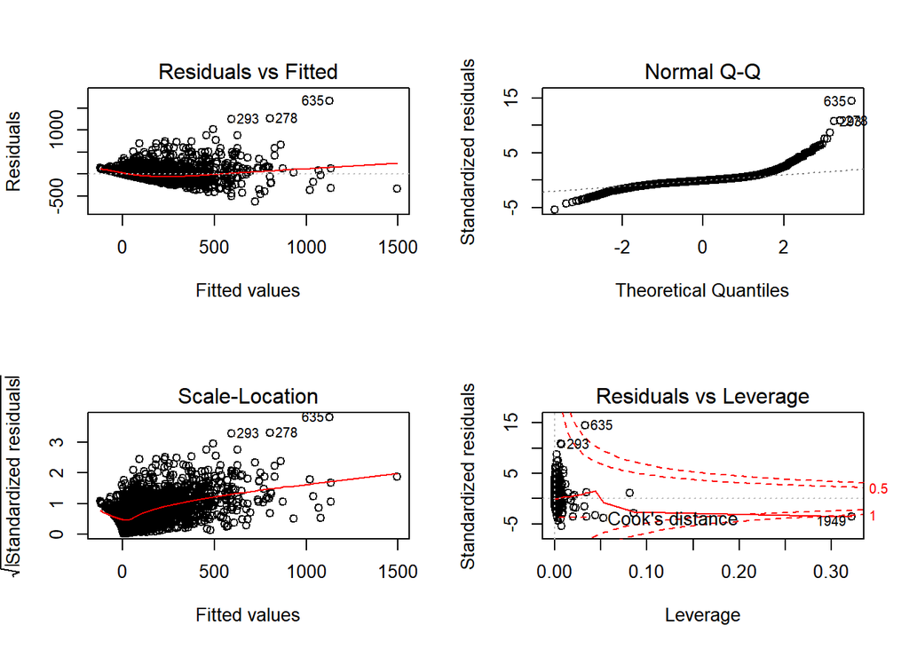

```r
#mostriamo
par(mfrow=c(2,2))
plot(OLS_Multiple2)
```

### Raffinamento del modello

Una volta identificati gli outliers, si procede alla loro eliminazione.

```r
#eliminiamo gli outliers
no_outliers<-lm(data = train1[c(-1949,-293,-278,-635),], revenue~. -original_language)
summary(no_outliers)
```

```
##
## Call:
## lm(formula = revenue ~ . - original_language, data = train1[c(-1949,
##     -293, -278, -635), ])
##
## Residuals:
##     Min      1Q  Median      3Q     Max
## -606.91  -50.77  -12.32   31.78 1034.75
##
## Coefficients:
##                Estimate Std. Error t value Pr(>|t|)
## (Intercept)  -235.40978   13.88923  -16.95   <2e-16 ***
## budget          2.78190    0.04371   63.64   <2e-16 ***
## popularity      2.27511    0.14497   15.69   <2e-16 ***
## runtime        -0.23387    0.09827   -2.38   0.0174 *
## vote_average   38.66223    2.25948   17.11   <2e-16 ***
## ---
## Signif. codes:  0 '***' 0.001 '**' 0.01 '*' 0.05 '.' 0.1 ' ' 1
##
## Residual standard error: 110.2 on 4077 degrees of freedom
## Multiple R-squared:  0.5892, Adjusted R-squared:  0.5888
## F-statistic:  1462 on 4 and 4077 DF,  p-value: < 2.2e-16
```

```r
confint(no_outliers)
```

```
##                     2.5 %       97.5 %
## (Intercept)  -262.6402580 -208.1793071
## budget          2.6962027    2.8676015
## popularity      1.9908871    2.5593248
## runtime        -0.4265331   -0.0412049
## vote_average   34.2324162   43.0920513
```

Si noti come il grado di significatività delle variabili aumenti.  
Segue il confronto AIC dei vari modelli per vedere quali hanno una bontà di adattamento migliore. In questo caso si osserva come l’AIC più basso è quello dell’OLS multiplo senza outliers.

```r
AIC(OLS_Multiple) #con tutte le variabili
```

```
## [1] 50505.44
```

```r
AIC(OLS_Multiple2) #senza original_language
```

```
## [1] 50502.19
```

```r
AIC(no_outliers) #senza outliers
```

```
## [1] 49978.07
```

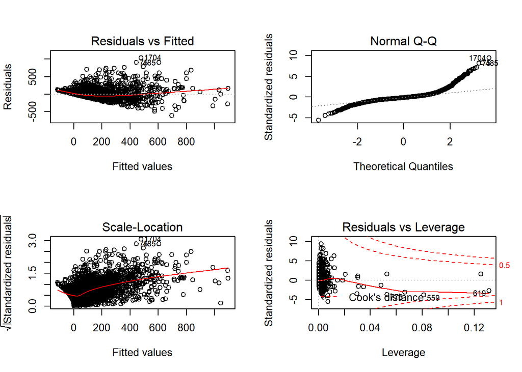

```r
#mostriamo il plot della regressione definitiva
par(mfrow=c(2,2))
plot(no_outliers)
```

```r
#jarque bera test
library(tseries)
jarque.bera.test(residuals(no_outliers))
```

```
##
##  Jarque Bera Test
##
## data:  residuals(no_outliers)
## X-squared = 30368, df = 2, p-value < 2.2e-16
```

Con questo test si afferma che gli errori non si distribuiscono in maniera normale, dato il basso p-value si rifiuta l’ipotesi H0 (normalità degli errori) a favore dell’ipotesi H1 (non normalità degli errori).

```r
#breush pagan
library(lmtest)
bptest(no_outliers, studentize = FALSE)
```

```
##
##  Breusch-Pagan test
##
## data:  no_outliers
## BP = 4177.7, df = 4, p-value < 2.2e-16
```

Con il Breusch-Pagan si afferma che gli errori sono eteroschedastici, rifiutando l’ipotesi H0 di omoschedasticità.

```r
#durbin watson
dwtest(no_outliers, alternative = c("two.sided"))
```

```
##
##  Durbin-Watson test
##
## data:  no_outliers
## DW = 1.9289, p-value = 0.0213
## alternative hypothesis: true autocorrelation is not 0
```

Il test è significativo, quindi non si può escludere l’autocorrelazione dei residui.

```r
#previsione su film Spider-Man: Far from home (2019)
spiderman=data.frame(budget=160000000, runtime=123, popularity=250000000, vote_average=7.5, original_language="en")
predict(no_outliers, spiderman , level = 0.95, interval = "prediction")
```

```
##          fit       lwr        upr
## 1 1013880854 945215713 1082545996
```

E’ stato preso in esame il film “Spider-Man: Far from home” uscito nel 2019, ed è stata effettuata una previsione degli incassi.